# Analyzing Airbnb Price Data

Camilla Bendetti and Jane Roarty

05/03/2020

## Introduction

[Airbnb](https://www.airbnb.com/), an online platform where homeowners can rent our private rooms and properties to guests, has become increasingly popular over the past several years. New York City, a popular tourist destination, has a demand for Airbnb listings with the constant traffic of people looking for housing accommodations. The following projects analyze the prices of Airbnb rental listings in all five boroughs of New York City. The five boroughs of New York City include Manhattan, Brooklyn, Queens, The Bronx, and State Island. The first project explores data from October 2018 and creates a series of linear regression models. The second project uses LASSO and KNN to create more flexible models.

Our data was collected by [Airbnb](http://insideairbnb.com/get-the-data.html). Our first step was to clean the data. We used data from October 2018.

## Project 1: Introduction to Statistical Modeling

What factors affect the price of Airbnb listings in New York City?

We can see from the histogram of the price per night that the data has a right skew with the cost generally between $50 and $500 per night but has outliers all the way up to $3,000.

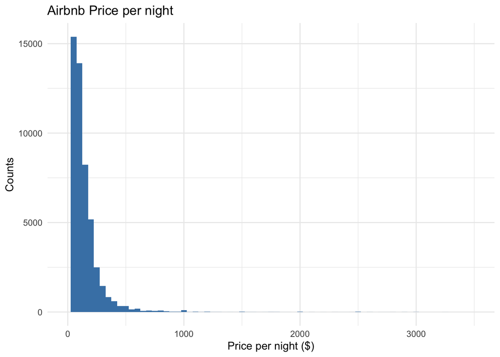

To identify useful predictors for our model, we created a series of plots from which we looked for trends.

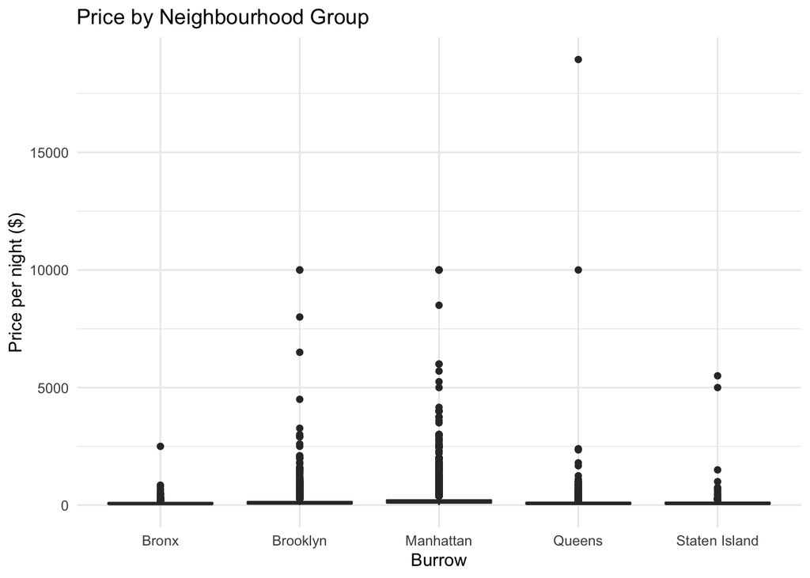

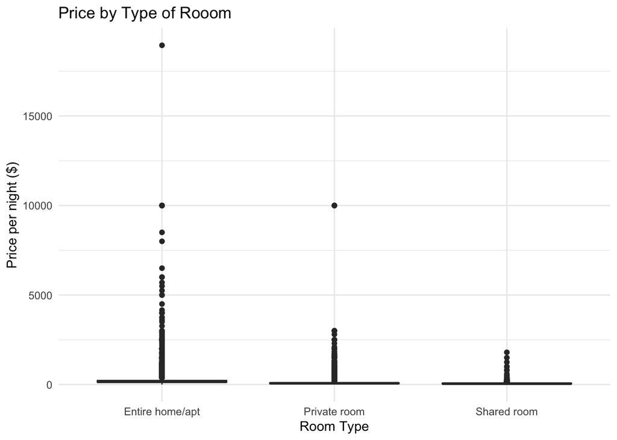

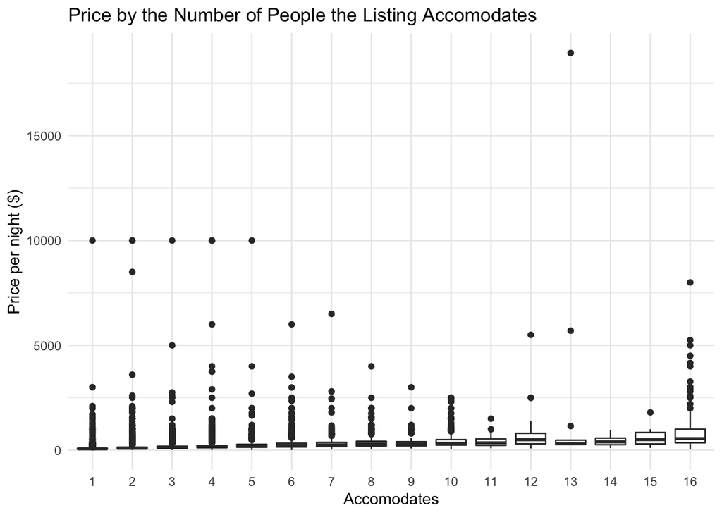

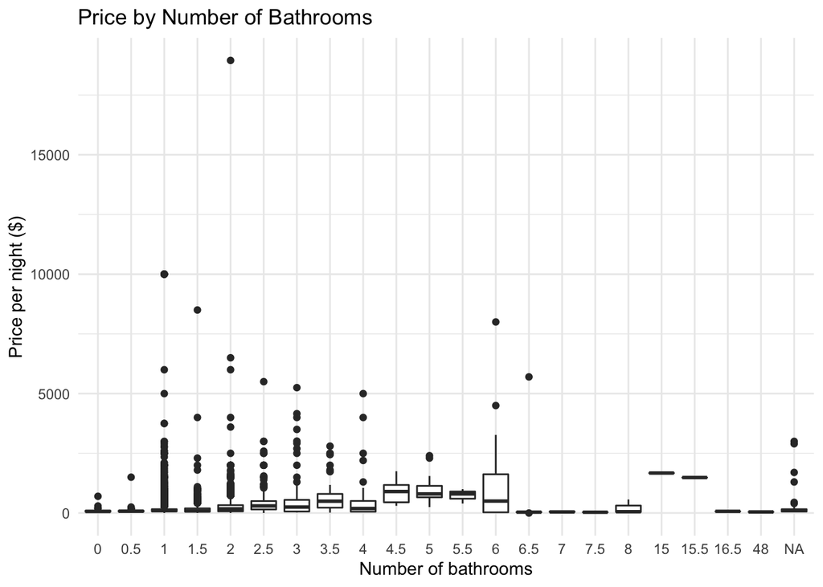

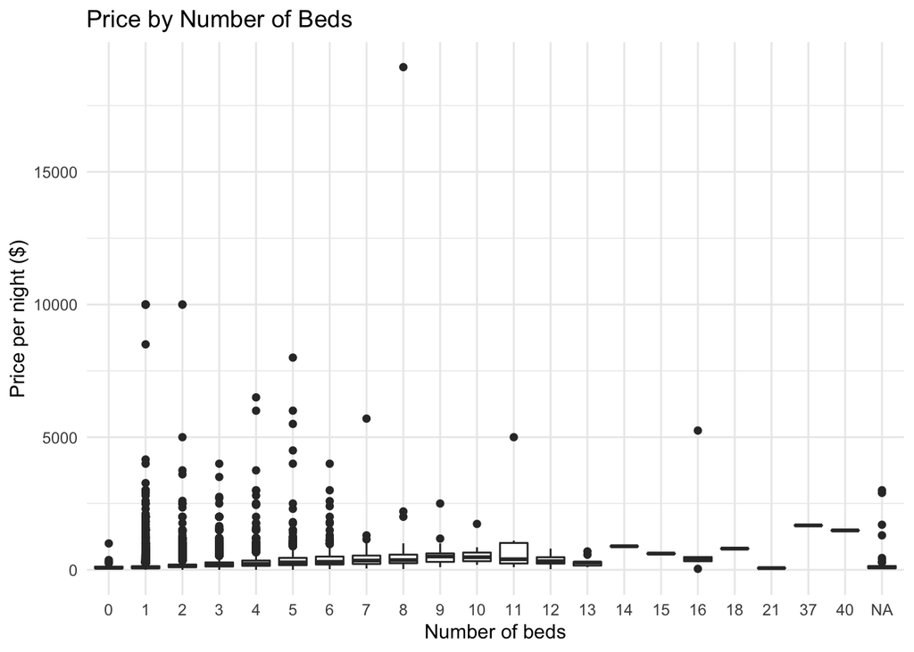

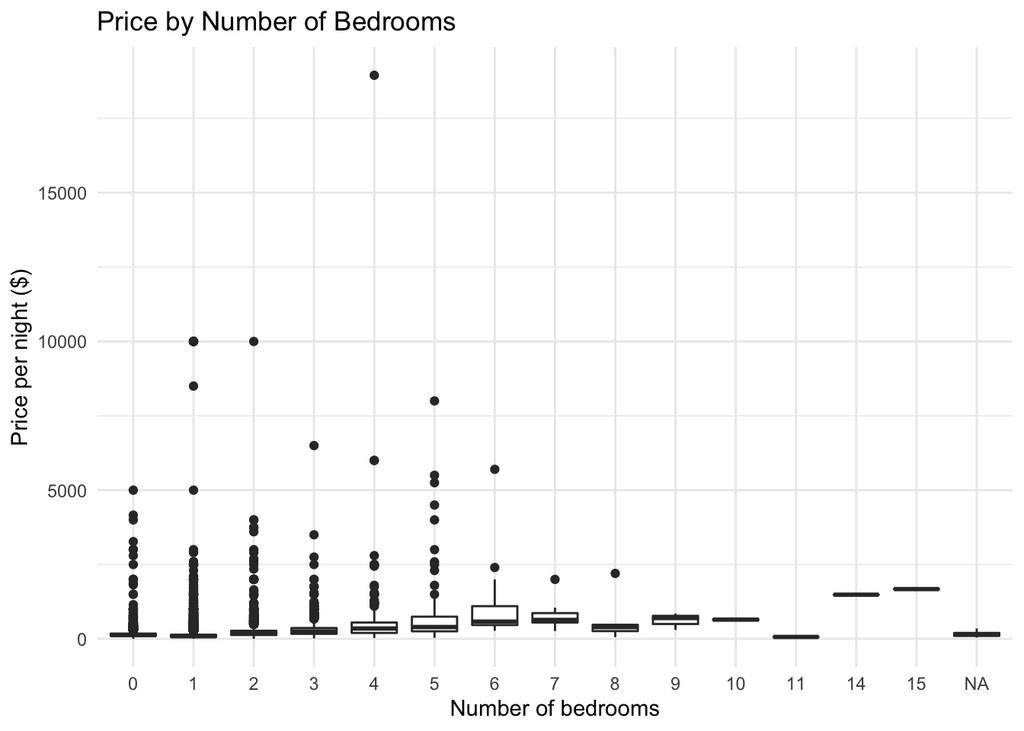

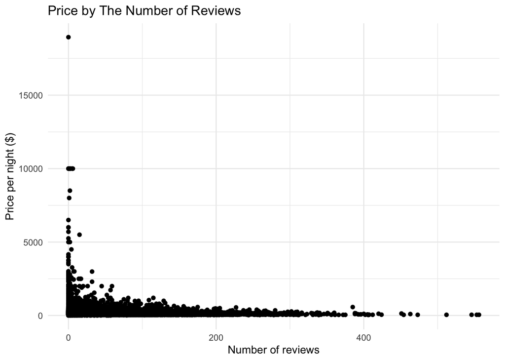

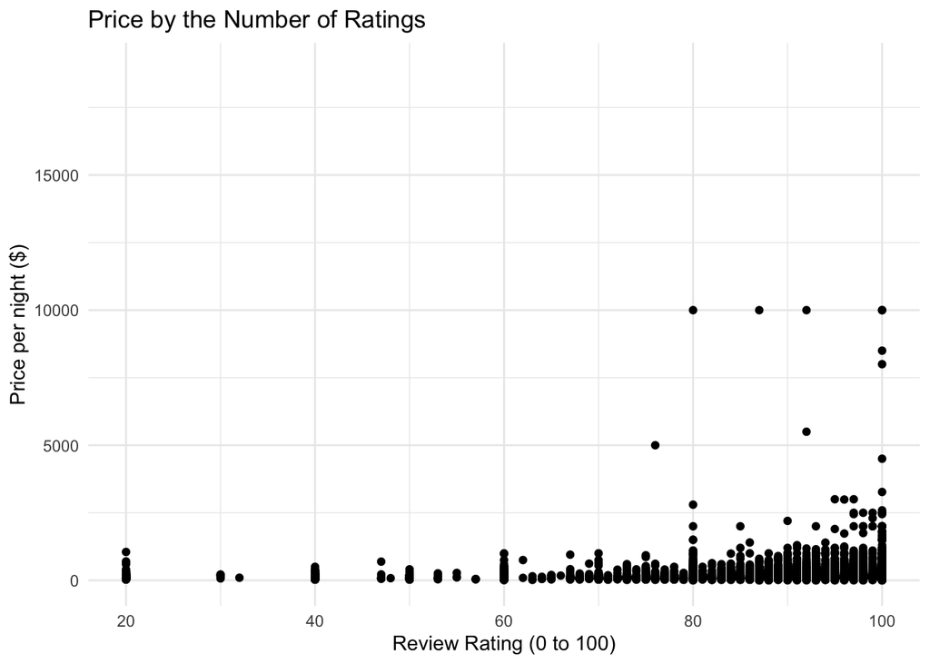

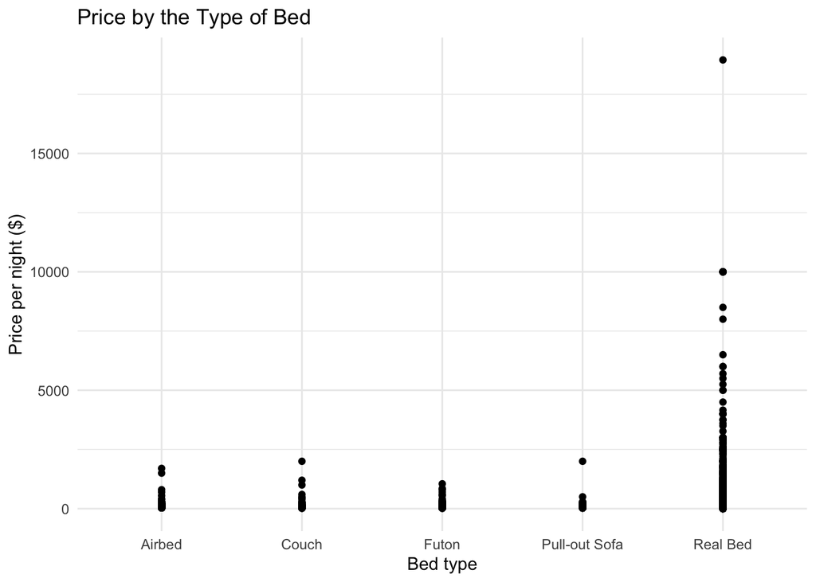

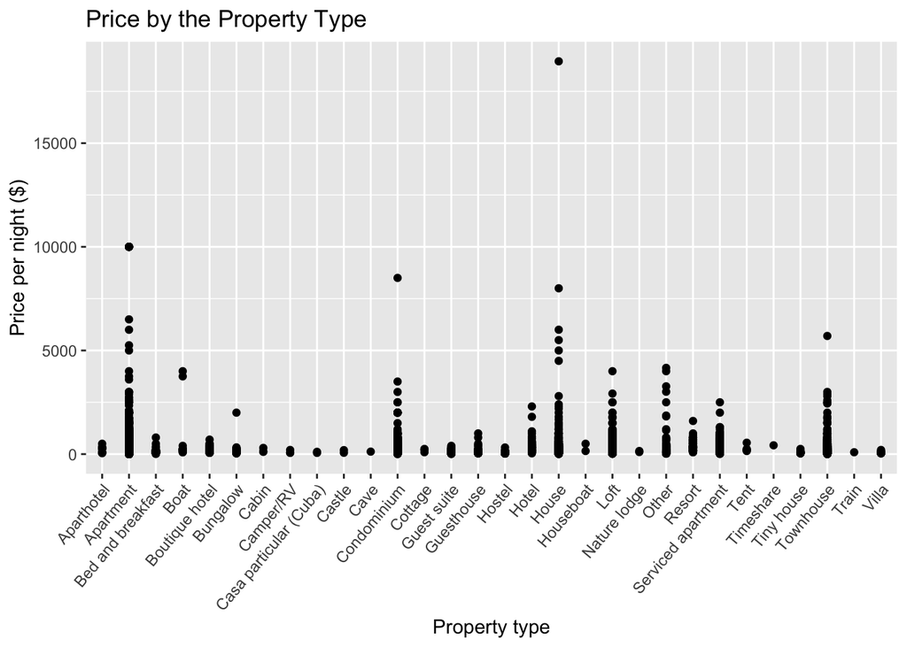

For our preliminary model, we included predictors that showed some trend in the plots, or that seemed important enough to consider. We ultimately included the following in the model:

- The number of beds in a listing ***
- Neighbourhood_group_cleansed (Burrow): Which burrow the listing was located
- Manhattan and Brooklyn ***: If the listing was located in Manhattan or Brooklyn
- Room Type: Shared or Private
- Accommodates: How many people the listing can accomodate
- Bathrooms: Number of bathrooms
- Bedrooms: Number of bedrooms
- Tv: If there is a TV in the listing
- Bus: If the listing is located near the bus
- Host_response_time: How long it takes for the owner of the listing to respond to requests
- Property_type: Resport, Boutique Hotel, Castle, Hotel, Loft
- Number_of_reviews: How many reviews the listing has
- Review_scores_rating: What is the rating of the listing

In order to analyze these data, we needed to consider the different types of Airbnbs that exist and how they would be coded differently in the data. We looked closely at the outliers on plots of different variables to understand different ways that owners advertised their listings.

The first variable we considered was the number of beds at a listing. While we can see from the general trend that listings with more beds generally cost more, there are also a lot of interesting outliers. We can see that there are more outliers when there are fewer beds. This is likely because the more expensive areas only have smaller places to stay. We also see outliers where more beds are cheaper than the trend, possibly because some listings that have 20+ beds are actually hostels advertised on Airbnb. Keeping all other variables consistent, we found that the price of a listing increased by 53 dollars per night per bathroom and that there is an average difference of 261 dollars per night between different property types. We decided to keep these variables based on the difference in $R^{2}$ from when we included the variables and when we did not and an ANOVA test.

We scraped a number of the variables to more easily quantify them. We scraped the `amenities` variable for any listings with the words ‘TV,’ ‘Cable TV,’ and ‘Cable,’ and `transit` for ‘bus,’ ‘walking,’ and ‘subway.’ We found ‘bus’ to be statistically significant. One thing that we had to overcome was different words that people used to describe these amenities. For example, the host has the ability to list the amenities that their listing has, there is not a checklist that includes the same words for each host to choose from. Therefore, for example, when scraping to amenities regarding the subway we looked for instances that included the words `trains`, `Subway`, `TRAIN`, `SUBWAY`, and `lines` because hosts used different words to describe the subway We found that wifi had little effect on the price for a listing We attributed this to the fact that there is an abundance of free wifi in shops and restaurants like Starbucks and McDonalds for visitors to use. the variable `reviews`, we found that the fewer the reviews, the more expensive the listing and the faster the host response time, the less expensive the listing.

Some limitations that we faced were that we based our model only on data from October 2018 in order to eliminate differences in season. In the future, it would be interesting to explore seasonality. Since we were only able to get our $R^{2}$ value up to 0.4025, we know a lot of variation goes unexplained. Since we still have statistically significant variables, we know they impact the price, but some variables that account for much variation are not included in Inside Airbnb’s data set.

We would also like to briefly discuss the ethical considerations of this project. We would like to acknowledge that while Airbnb is very popular and useful, it is causing rent prices for locals to skyrocket. This forces locals to move from their homes in order to afford housing. We hope that looking at pricing data could help to solve this issue and reduce the displacment of individuals effected by increase tourism. Data privacy is also something important to consider. In August 2018 Airbnb started suing NYC for a [law](https://www.recode.net/2018/8/24/17779208/airbnb-suing-new-york-city-user-data-hosts-privacy-brian-chesky) that they passed in July. The law would require “Airbnb and other home-sharing companies to share hosts’ names and addresses with the city’s enforcement agency on a monthly basis” in order to stop illegal listings. Airbnb argues that “the law violates its users’ privacy and constitutional rights.”

## Project 2: Statistical Machine Learning

This project was completed in our Statistical Machine Learning course. We used different techniques in order to select variables and create a model. We tried both LASSO and KNN to create more flexible models.

### Clean

First, we cleaned the data again. We reduced the size of the data set to prevent redundancy and to simplify our task going forward. We removed id, latitude, longitude, is_location_exact, availability_30, and require_guest_profile_picture. We took out id because it is just an indexed label without information, latitude and longitude are captured more meaningfully in neighborhood and borough, and we didn’t think availability_30 and require_guest_profile_picture gave significant information that predicted price.

### Analyze

From this, we can see a general positive linear trend likely because the more people the listing accommodates, the larger the listing the more expensive.

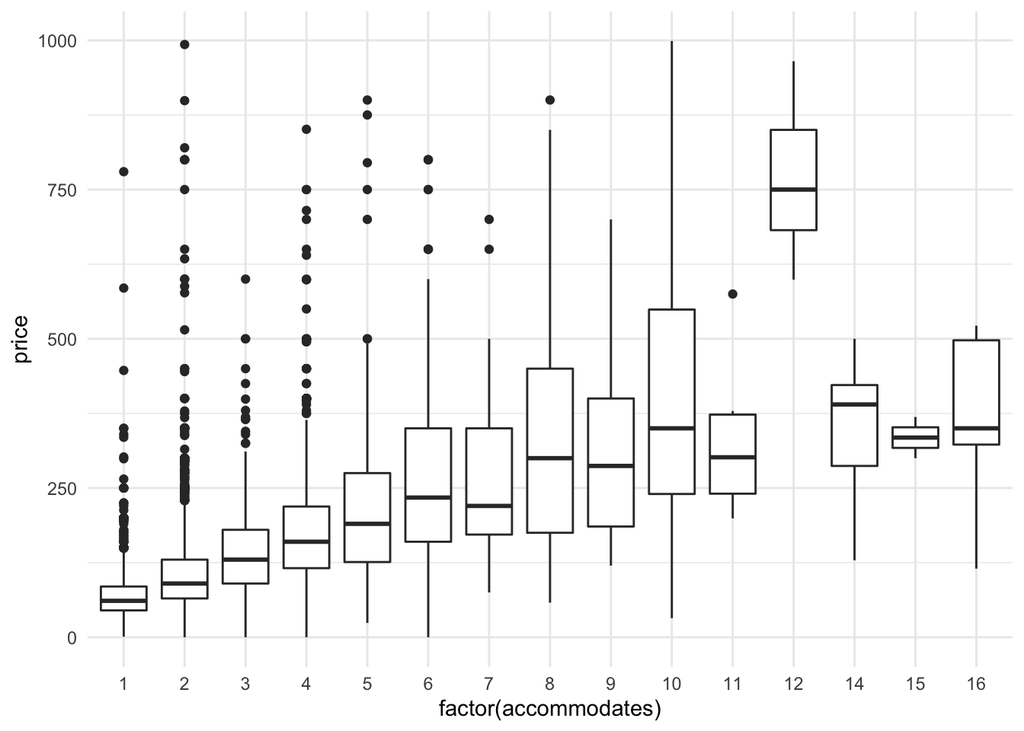

The lower price listings probably have a quicker turnover of guests so there might be more reviews so this might not be the best predictor - it also does not say whether they are good or bad reviews so the number of reviews does not necessarily mean more expensive

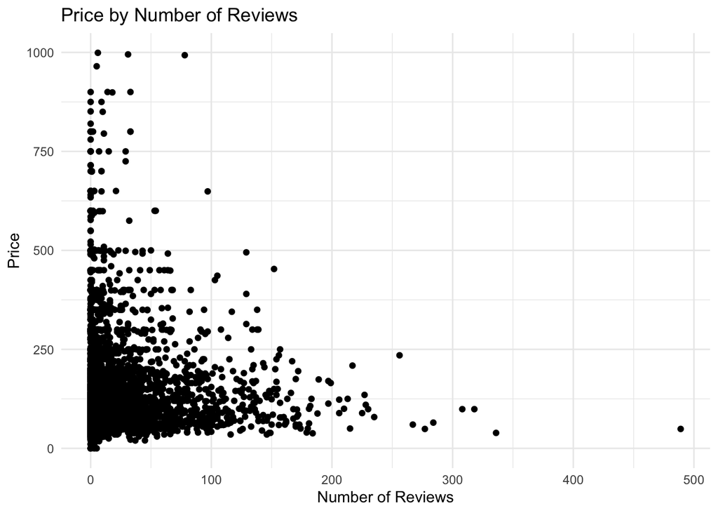

[figure not shown]

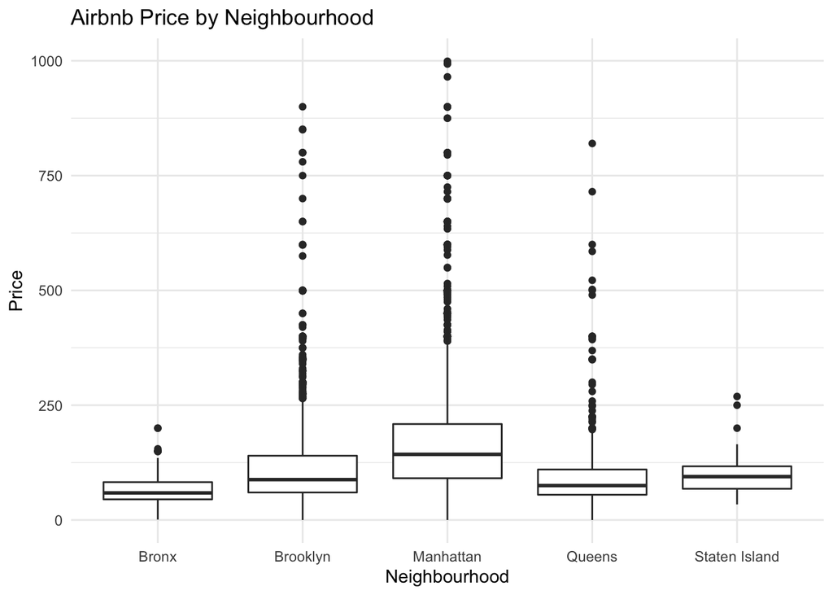

### Model

To begin building our model, we first created a smaller dataset called airbnb_small. We used a LASSO model for variable selection but it was not a good fit because it was too rigid. Instead, we built a KNN model to have more flexibility with our data. With our original dataset, we exhausted the vector so we went back and took out some more predictors including amenities, calendar_updated, bed_type, host_response_rate, and host_response_time.

#### LASSO

Below, is a plot of our LASSO model.

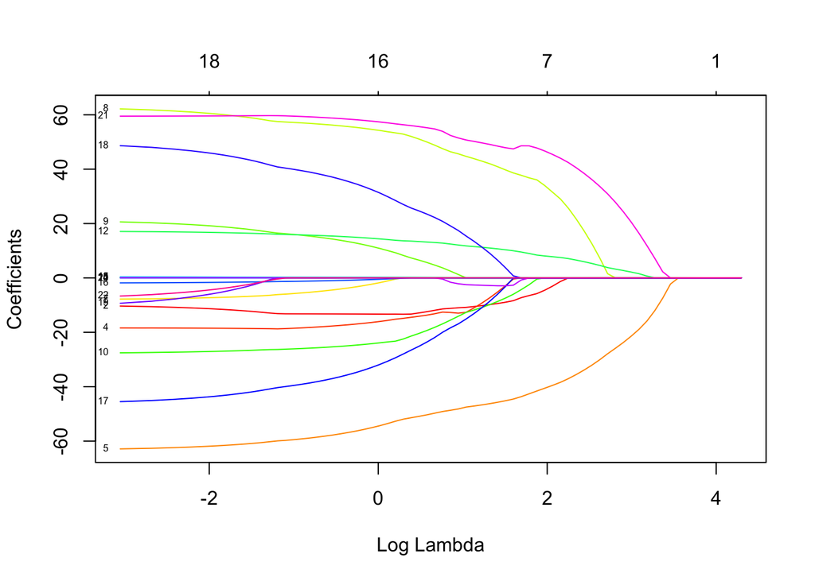

```
##  [1] "host_is_superhostf"               "host_is_superhostt"
##  [3] "host_has_profile_picf"            "host_has_profile_pict"
##  [5] "room_typePrivate room"            "room_typeShared room"
##  [7] "accommodates"                     "bathrooms"
##  [9] "bedrooms"                         "beds"
## [11] "square_feet"                      "guests_included"
## [13] "minimum_nights"                   "maximum_nights"
## [15] "number_of_reviews"                "review_scores_rating"
## [17] "instant_bookablet"                "is_business_travel_readyt"
## [19] "reviews_per_month"                "neighbourhood_groupBrooklyn"
## [21] "neighbourhood_groupManhattan"     "neighbourhood_groupQueens"
## [23] "neighbourhood_groupStaten Island"
```

We uesd a lambda of 7.56 because that is the bestTune of our model.

LASSO gave us 8 significant predictors which we hard coded into a smaller data set called airbnb_small. We used this for our KNN model and for representing the relationship between price and these significant predictors.

#### KNN model

We found KNN to be the best model. We also tried GAM but that did not work because it was trying to smooth with categorical values. The parametric model, LASSO, was too rigid so we fit our data to a non-parametric model, KNN. There were a lot of categorical variables so GAM could not smooth the function.

Below, is a plot of our first KNN model.

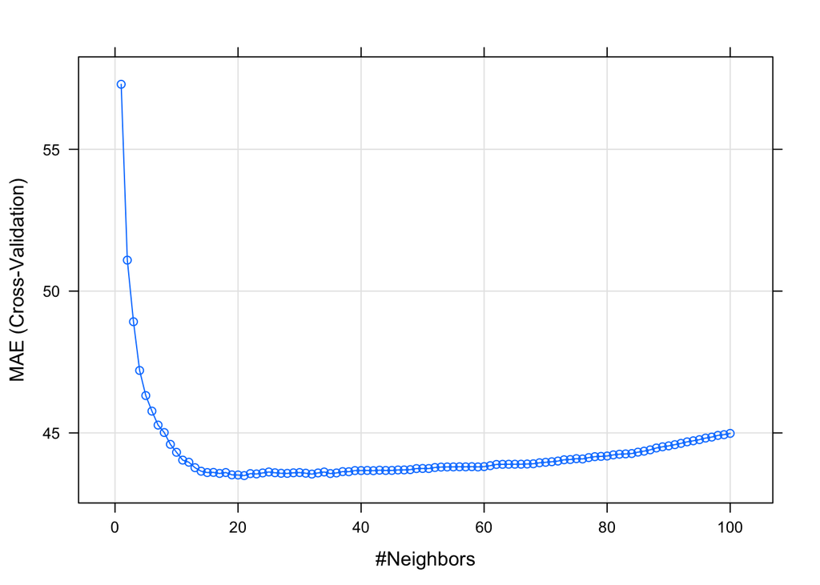

### Summarize

One of the drawbacks of KNN is that you can’t see the relationship between the predictors. To look at the relationships between significant predictors and price, we used the raw data to make visualizations.

Our final predictors for price based on the LASSO model were host_is_superhost, room_type, bathrooms, bedrooms, guests_included, review_scores_rating, reviews_per_month, neighbourhood_group.

The plot below shows the relationship between room type and price. According to the LASSO model, room type was the most significant predictor. From this visualization, we can see that an entire apartment/home has a significantly higher price than a private room and a shared room. This makes sense because you don’t have to split the cost with others in an entire house, so it costs more.

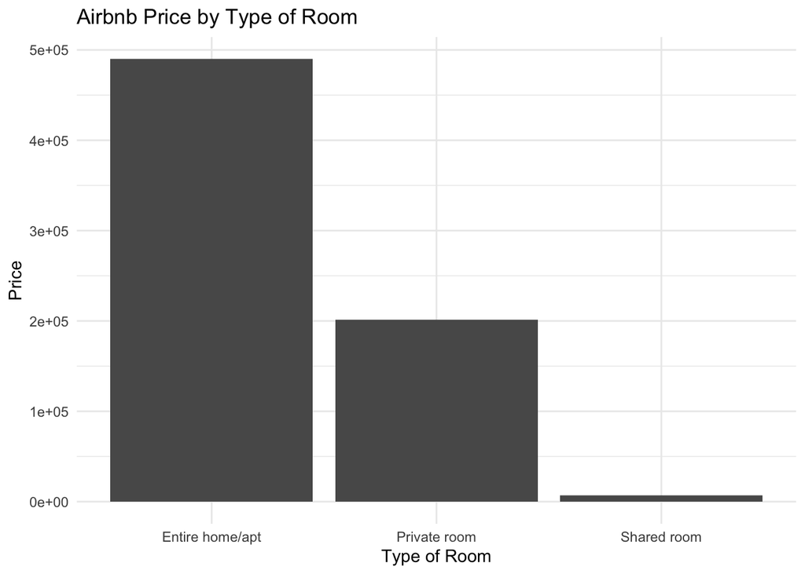

In this boxplot, we are showing the relationship between price and number of bedrooms. Overall, there is an increase in price with an increase in the number of bedrooms. This makes sense because more bedrooms take up more space and can hold more people.

[figure not shown]

We also made a boxplot for super host but decided not to include it because the relationship was not very obvious.

[figure not shown]

The plot below of the relationship between the number of guests included and the price of the listing shows a positive, generally linear trend. As guests increase, price increases.

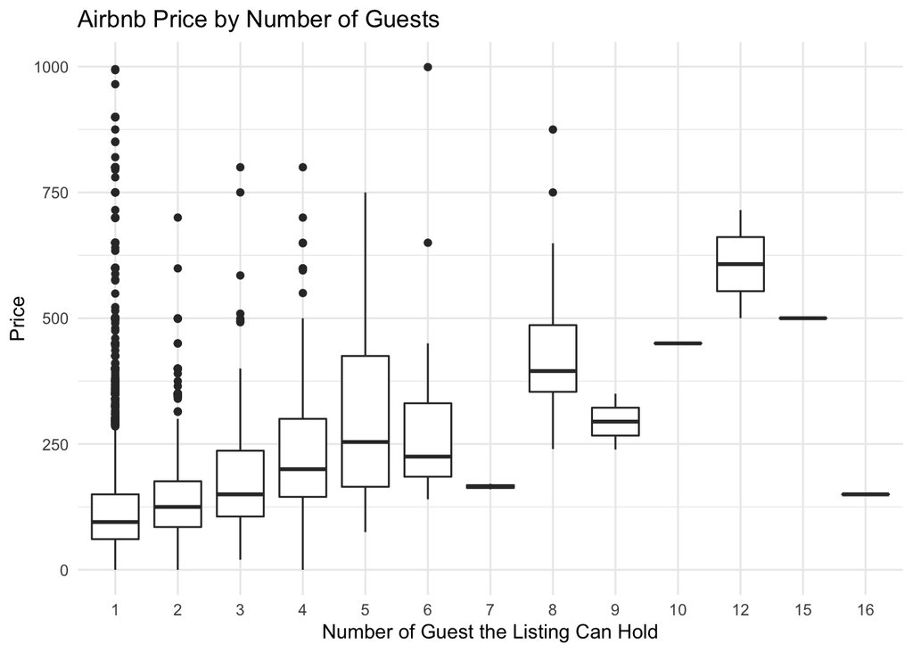

It seems from this plot of review score ratings and price that for higher ratings of the listing there is a positive trend. Most of the data here is concentrated toward higher ratings.

[figure not shown]

This plot shows the relationship between reviews per month and price. Most of the data is concentrated toward a smaller number of reviews. It does not consider whether the reviews are good or bad so a lot of good reviews could explain why the price is higher while many bad reviews could explain why it’s lower. We don’t have this information, however, which makes it harder to interpret.

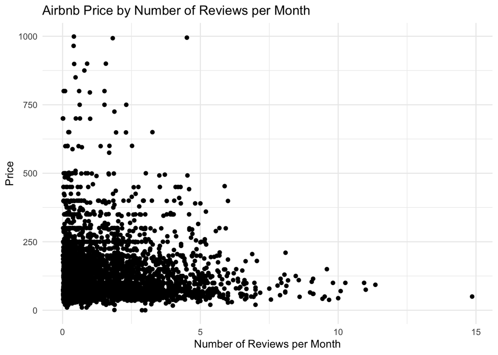

[figure not shown]

Selected listings: We looked at the average MAE for listings in certain subsets of our data. We first looked at the average MAE for a private room in Manhattan which had a value of 39.79714. We then looked at the average MAE for an entire home or apartment in Brooklyn which had an MAE of 70.75217. Manhattan listings, in general, are pretty expensive so a 40 dollar error is not too large. While a 70 dollar error seems pretty big, it is also only for entire homes and apartments which will be much more expensive.